# Trip to Asymptotia

Tejus

13/09/2020

## Introduction

- Asymptotics refers to the behavior of estimators as the sample size goes to infinity.
- Our very notion of probability depends on the idea of asymptotics. For example, many people define probability as the proportion of times an event would occur in infinite repetitions. That is, the probability of a head on a coin is 50% because we believe that if we were to flip it infinitely many times, we would get exactly 50% heads.
- We can use asymptotics to help is figure out things about distributions without knowing much about them to begin with.
- A profound idea along these lines is the Central Limit Theorem. **It states that the distribution of averages is often normal, even if the distribution that the data is being sampled from is very non-normal.**
- This helps us create robust strategies for creating statistical inferences when we’re not willing to assume much about the generating mechanism of our data.

## Asymptotics

- Asymptotics are incredibly useful for simple statistical inference and approximations.
- Asymptotics form the basis of frequency interpretation of probabilities. { Approaching p(Head) = 0.5 }

## Law of large numbers (LLN)

- Average ( mean of x’s) limits to what it’s estimating, the population mean. Let’s take an example.
- $$\bar X_n$$
  could be the average of results of `n` coin flips. As we flip a fair coin over & over, it eventually converges to true probability of head.

## Simulation Example 1

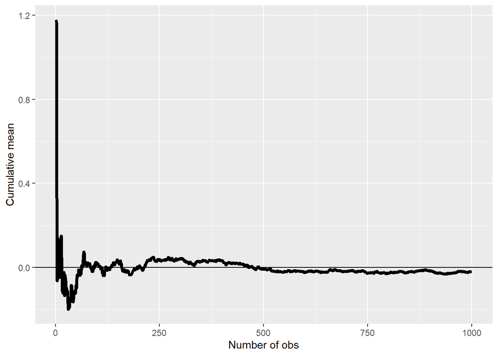

```r
# Number of simulations
library(ggplot2)
n <- 1000

# Generate 1k numbers > cum sum > Divide each by respective sample size. Result : Mean.
means <- cumsum(rnorm(n)) / (1:n)

# Plot

g <- ggplot(data.frame(x = 1:n, y = means), aes(x = x, y = y))
g <- g + geom_hline(yintercept = 0) + geom_line(size = 1.5)
g <- g + labs(x = "Number of obs", y = "Cumulative mean")
g
```

We can see that number of simulations increase we get closer to true **population mean**. *In the sense it limits to what it’s estimating, the population mean.*

## Simulation Example 1 (Coin flips)

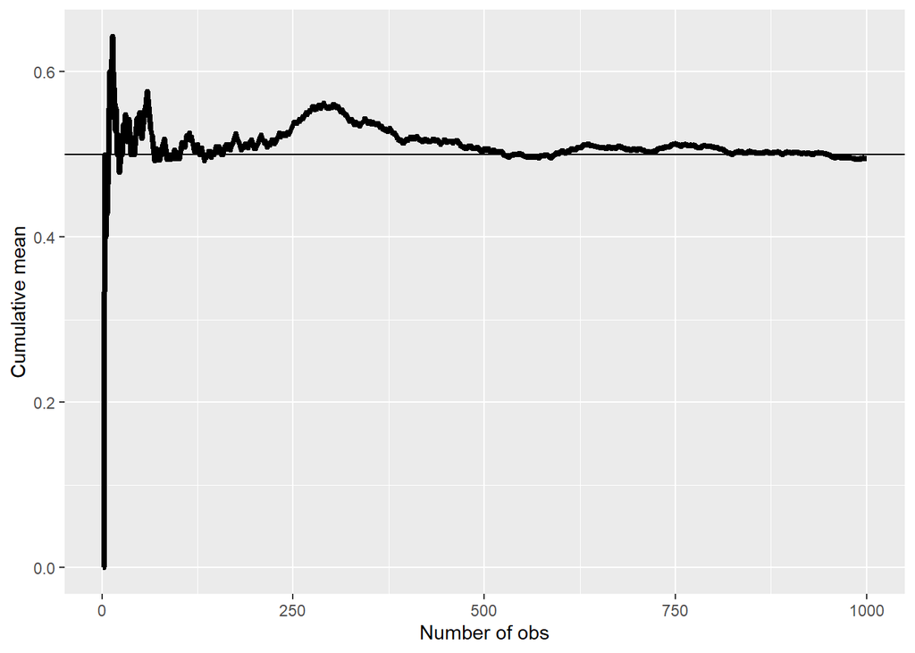

```r
# Number of simulations
n <- 1000

# Generate 1k numbers > cum sum > Divide each by respective sample size. Result : Mean.
means <- cumsum(sample(0:1, n, replace = TRUE)) / (1:n)

# Plot

g <- ggplot(data.frame(x = 1:n, y = means), aes(x = x, y = y))
g <- g + geom_hline(yintercept = 0.5) + geom_line(size = 1.5)
g <- g + labs(x = "Number of obs", y = "Cumulative mean")
g
```

## Important Points to Remember

- An estimator is consistent if it converges to what it wants to estimate. # LLN says that sample averages of IID sample is consistent for population mean.  
  # Typically, good estimators are consistent; Collect as many samples as possible.
- The sample variance & sample std deviation of IID random variables are consistent as well.

## Central Limit Theorem

- States that distribution of averages of IID variables (properly normalised) becomes that of a std normal as the sample size increases.
- The result is that
  $$\frac{\bar X_n - \mu}{\sigma / \sqrt{n}}=
  \frac{\sqrt n (\bar X_n - \mu)}{\sigma}
  = \frac{\mbox{Estimate} - \mbox{Mean of estimate}}{\mbox{Std. Err. of estimate}}$$
  has a distribution like that of a standard normal for large $n$.
- The useful way to think about the CLT is that $\bar X_n$ is approximately $N(\mu, \sigma^2 / n)$ (Normally distributed)

## Confidence Intervals

- According to the CLT, the sample mean, $\bar X$, is approximately normal with mean $\mu$ and sd $\sigma / \sqrt{n}$
- $\mu + 2 \sigma /\sqrt{n}$ is pretty far out in the tail (only 2.5% of a normal being larger than 2 sds in the tail)
- Similarly, $\mu - 2 \sigma /\sqrt{n}$ is pretty far in the left tail (only 2.5% chance of a normal being smaller than 2 sds in the tail)
- So the probability $\bar X$ is bigger than $\mu + 2 \sigma / \sqrt{n}$ or smaller than $\mu - 2 \sigma / \sqrt{n}$ is 5%
- Or equivalently, the probability of being between these limits is 95%
- The quantity $\bar X \pm 2 \sigma /\sqrt{n}$ is called a 95% interval for $\mu$
- The 95% refers to the fact that **if one were to repeatedly get samples of size $n$ from this population**, about 95% of the intervals obtained would contain $\mu$
- The 97.5th quantile is 1.96 (so I rounded to 2 above)
- For 90% interval you want (100 - 90) / 2 = 5% in each tail
  - So you want the 95th percentile (1.645)